# R Notebook

Loading data

```r
sms_raw <- read.csv("C:/Users/Sagar Ghiya/Desktop/sms_spam.csv", stringsAsFactors = FALSE)
```

Checking structure of data

```r
str(sms_raw)
```

```
## 'data.frame':    5574 obs. of  2 variables:
##  $ type: chr  "ham" "ham" "spam" "ham" ...
##  $ text: chr  "Go until jurong point, crazy.. Available only in bugis n great world la e buffet... Cine there got amore wat..." "Ok lar... Joking wif u oni..." "Free entry in 2 a wkly comp to win FA Cup final tkts 21st May 2005. Text FA to 87121 to receive entry question("| __truncated__ "U dun s…
```

Converting sms type(ham or spam) into factor

```r
sms_raw$type <- factor(sms_raw$type)
```

Verifying the structure

```r
str(sms_raw$type)
```

```
##  Factor w/ 2 levels "ham","spam": 1 1 2 1 1 2 1 1 2 2 ...
```

Check total number of ham and spam

```r
table(sms_raw$type)
```

```
##
##  ham spam
## 4827  747
```

Loading text mining package tm. Creating temporary Corpus to store text data

```r
library(tm)
sms_corpus <- VCorpus(VectorSource(sms_raw$text))
```

```r
print(sms_corpus)
```

```
## <<VCorpus>>
## Metadata:  corpus specific: 0, document level (indexed): 0
## Content:  documents: 5574
```

Inspecting the structure for corpus

```r
inspect(sms_corpus[1:2])
```

```
## <<VCorpus>>
## Metadata:  corpus specific: 0, document level (indexed): 0
## Content:  documents: 2
##
## [[1]]
## <<PlainTextDocument>>
## Metadata:  7
## Content:  chars: 111
##
## [[2]]
## <<PlainTextDocument>>
## Metadata:  7
## Content:  chars: 29
```

```r
as.character(sms_corpus[[1]])
```

```
## [1] "Go until jurong point, crazy.. Available only in bugis n great world la e buffet... Cine there got amore wat..."
```

```r
lapply(sms_corpus[1:2], as.character)
```

```
## $`1`
## [1] "Go until jurong point, crazy.. Available only in bugis n great world la e buffet... Cine there got amore wat..."
##
## $`2`
## [1] "Ok lar... Joking wif u oni..."
```

Now next task is to make data consistent. That will be achieved by series of steps

Converting everything into lowercase so that “Upper” and “upper” are same when we analyze

```r
sms_corpus_clean <- tm_map(sms_corpus,content_transformer(tolower))
```

Checking transformation

```r
as.character(sms_corpus[[1]])
```

```
## [1] "Go until jurong point, crazy.. Available only in bugis n great world la e buffet... Cine there got amore wat..."
```

```r
as.character(sms_corpus_clean[[1]])
```

```
## [1] "go until jurong point, crazy.. available only in bugis n great world la e buffet... cine there got amore wat..."
```

Removing numbers as we don’t need them for this code

```r
sms_corpus_clean <- tm_map(sms_corpus_clean,removeNumbers)
```

Removing stopwords

```r
sms_corpus_clean <- tm_map(sms_corpus_clean,removeWords, stopwords())
```

Removing Punctuation

```r
sms_corpus_clean <- tm_map(sms_corpus_clean, removePunctuation)
```

Loading package snowballC for preparing wordcloud Also stemming document i.e learning will become learn.

```r
library(SnowballC)
sms_corpus_clean <- tm_map(sms_corpus_clean, stemDocument)
```

Removing White space

```r
sms_corpus_clean <- tm_map(sms_corpus_clean, stripWhitespace)
```

```r
lapply(sms_corpus_clean[1:2], as.character)
```

```
## $`1`
## [1] "go jurong point crazi avail bugi n great world la e buffet cine got amor wat"
##
## $`2`
## [1] "ok lar joke wif u oni"
```

```r
sms_dtm <- DocumentTermMatrix(sms_corpus_clean)
```

Another way to clean the corpus.

```r
sms_dtm2 <- DocumentTermMatrix(sms_corpus, control=list(tolower=TRUE, removeNumbers=TRUE,stopwords =TRUE, removePunctuation=TRUE, stemming=TRUE))
```

```r
sms_dtm
```

```
## <<DocumentTermMatrix (documents: 5574, terms: 6611)>>
## Non-/sparse entries: 42653/36807061
## Sparsity           : 100%
## Maximal term length: 40
## Weighting          : term frequency (tf)
```

```r
sms_dtm2
```

```
## <<DocumentTermMatrix (documents: 5574, terms: 7005)>>
## Non-/sparse entries: 43742/39002128
## Sparsity           : 100%
## Maximal term length: 40
## Weighting          : term frequency (tf)
```

Dividing the data into train and test

```r
sms_dtm_train <- sms_dtm[1:4180,]
sms_dtm_test <- sms_dtm[4181:5574,]
```

Dividing labels into train and test

```r
sms_train_labels <- sms_raw[1:4180,]$type
sms_test_labels <- sms_raw[4181:5574,]$type
```

Checking to see if spam are divided equally in both test and train

```r
prop.table(table(sms_train_labels))
```

```
## sms_train_labels
##       ham      spam
## 0.8648325 0.1351675
```

```r
prop.table(table(sms_test_labels))
```

```
## sms_test_labels
##       ham      spam
## 0.8694405 0.1305595
```

Loading Wordcloud package Creating wordcloud for cleaned corpus

[figure not shown]

```r
library(wordcloud)
wordcloud(sms_corpus_clean, min.freq=50,random.order=FALSE)
```

Sperating sam and ham messages to visualize them

```r
spam <- subset(sms_raw, type =="spam")
ham <- subset(sms_raw, type =="ham")
```

Wordcloud for spam

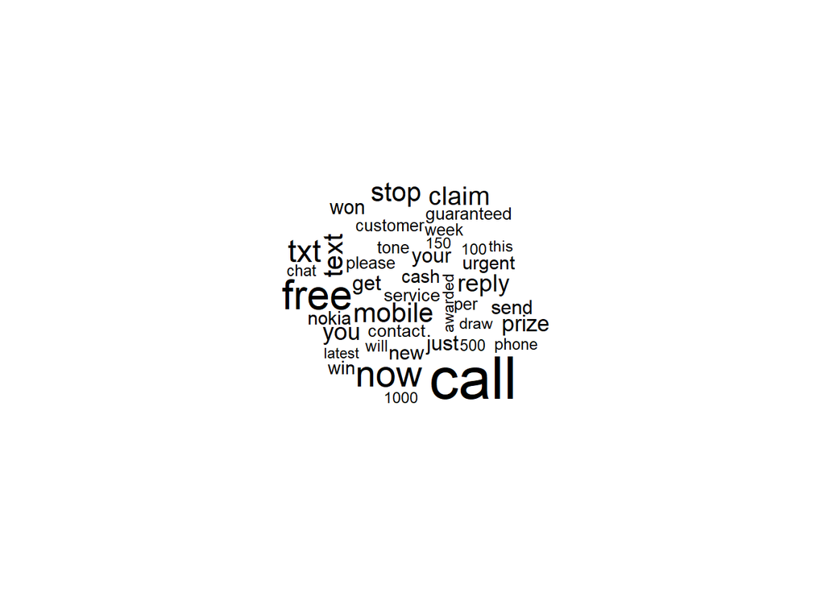

```r
wordcloud(spam$text, max.words=40,scale=c(3,0.5))
```

Wordcloud for ham

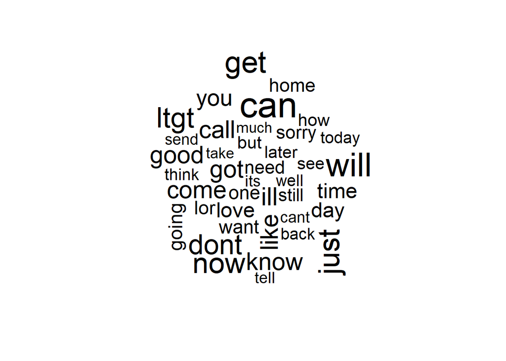

```r
wordcloud(ham$text, max.words=40, scale=c(3,0.5))
```

Only keeping words that atleast occur 5 times

```r
sms_freq_words <- findFreqTerms(sms_dtm_train,5)
```

Checking structure

```r
str(sms_freq_words)
```

```
##  chr [1:1163] "â£wk" "â¦" "â" "abiola" "abl" "abt" "accept" ...
```

Train and test datasets having words which occur atleast 5 times

```r
sms_dtm_freq_train<- sms_dtm_train[ , sms_freq_words]
sms_dtm_freq_test <- sms_dtm_test[ , sms_freq_words]
```

Function to convert counts into “yes” and 0 counts into “No”

```r
convert_counts <- function(x) {
  x <- ifelse(x>0, "Yes", "No")
}
```

Transforming for train and test sets

```r
sms_train <- apply(sms_dtm_freq_train, MARGIN=2, convert_counts)
sms_test <- apply(sms_dtm_freq_test, MARGIN=2, convert_counts)
```

Building Naive Bayes model using e1071 package Prediciting for test set

```r
library(e1071)
sms_classifier <- naiveBayes(sms_train,sms_train_labels)
sms_test_predict <- predict(sms_classifier,sms_test)
```

Making crosstable matrix to check for accuracy

```r
library(gmodels)
CrossTable(sms_test_predict, sms_test_labels, prop.chisq=F, prop.t=F, dnn=c('predicted','actual'))
```

```
##
##
##    Cell Contents
## |-------------------------|
## |                       N |
## |           N / Row Total |
## |           N / Col Total |
## |-------------------------|
##
##
## Total Observations in Table:  1394
##
##
##              | actual
##    predicted |       ham |      spam | Row Total |
## -------------|-----------|-----------|-----------|
##          ham |      1203 |        20 |      1223 |
##              |     0.984 |     0.016 |     0.877 |
##              |     0.993 |     0.110 |           |
## -------------|-----------|-----------|-----------|
##         spam |         9 |       162 |       171 |
##              |     0.053 |     0.947 |     0.123 |
##              |     0.007 |     0.890 |           |
## -------------|-----------|-----------|-----------|
## Column Total |      1212 |       182 |      1394 |
##              |     0.869 |     0.131 |           |
## -------------|-----------|-----------|-----------|
##
##
```

Accuracy = (1203+162)/1394 = 97.92%

Adding laplace estimator to possibly increase accuracy if there is any data that appears in test set but not in train.

```r
library(e1071)
sms_classifier2 <- naiveBayes(sms_train,sms_train_labels, laplace=1)
sms_test_predict2 <- predict(sms_classifier2,sms_test)
```

Bulding crosstable matrix to check for accuracy

```r
library(gmodels)
CrossTable(sms_test_predict2, sms_test_labels, prop.chisq=F, prop.t=F, prop.r=F,dnn=c('predicted','actual'))
```

```
##
##
##    Cell Contents
## |-------------------------|
## |                       N |
## |           N / Col Total |
## |-------------------------|
##
##
## Total Observations in Table:  1394
##
##
##              | actual
##    predicted |       ham |      spam | Row Total |
## -------------|-----------|-----------|-----------|
##          ham |      1205 |        28 |      1233 |
##              |     0.994 |     0.154 |           |
## -------------|-----------|-----------|-----------|
##         spam |         7 |       154 |       161 |
##              |     0.006 |     0.846 |           |
## -------------|-----------|-----------|-----------|
## Column Total |      1212 |       182 |      1394 |
##              |     0.869 |     0.131 |           |
## -------------|-----------|-----------|-----------|
##
##
```

Accuracy = (1205 + 154)/1394 *100 = 97.49%

Thus laplace estimator helps to classify those set of data that appear in test dataset but not in train dataset. Because if we don’t use laplace estimator, there will be data with 0 probabilites. However, as in this case, using laplace estimators and adding 1 to the count, may tweak probability estimates and decrease accuracy. However our purpose is that they should be above some threshold.